# DNA Profile 2014

DSPG Business Innovation Team

7/9/2019

## 1. Read Data

Set year filter here.

```r
year <- 2014
path <- sprintf("./data/working/DNA_Aggregated/dna_%s.RDS", year)
dna.dt <- read_rds(path) %>%
  as.data.table()
```

This is the profiling for the year 2014.

## 2. Profile

Tidying the data.

```r
#Unlist columns
dna.dt <- dna.dt %>%
  dt_mutate(
    subject_codes = subject_codes %>% map_chr(.x = ., ~paste0(.x, collapse = ", "))
  )
```

General description.

```r
#Dimension
dna.dt %>%
  introduce()
```

```
##      rows columns discrete_columns continuous_columns all_missing_columns
## 1: 364489      33               33                  0                   0
##    total_missing_values complete_rows total_observations memory_usage
## 1:                19865        344714           12028137   1707121776
```

```r
#Tidy for head screenshot
dna.dt <- dna.dt %>%
  dplyr::select(c(an, title, body, publisher_name,
                  company_codes, subject_codes, everything()))
```

Names of variables.

```r
#Variable Names
names(dna.dt) %>% paste0(., collapse = ", ")
```

```
## [1] "an, title, body, publisher_name, company_codes, subject_codes, copyright, art, modification_datetime, company_codes_occur, company_codes_about, company_codes_lineage, snippet, publication_date, market_index_codes, credit, currency_codes, region_of_origin, ingestion_datetime, modification_dat…
```

[figure not shown]

```r
plot_str(dna.dt)
```

```r
#Structure of Data
str(dna.dt)
```

```
## Classes 'data.table' and 'data.frame':   364489 obs. of  33 variables:
##  $ an                       : chr  "LFSW000020140117ea1l0039v" "INDFED0020140110ea1a000c4" "BIWK000020140110ea1f000lq" "POLGOV0020140124ea1u002pn" ...
##  $ title                    : chr  "Tryptamines; Researchers from University of Valencia Report on Findings in Tryptamines" "CYMABAY THERAPEUTICS REPORTS ACQUISITION BY DIRECTOR KUMAR (California)" "Pharmacology; New Pharmacology Study Findings Recently Were Reported by I.N. Melas and Co-Research…
##  $ body                     : chr  "Our news editors obtained a quote from the research from the University of Valencia, \"In the present work, we "| __truncated__ "CymaBay Therapeutics Inc., a biopharmaceutical company, focuses on the discovery and development of various the"| __truncated__ "The…
##  $ publisher_name           : chr  "NewsRx.com" "HT Media Limited" "NewsRx.com" "NewsRx.com" ...
##  $ company_codes            : chr  ",unvale,unvale,unvale," ",mtblks,mtblks,mtblks,seexc," ",ucb," "" ...
##  $ subject_codes            : chr  "gsci, nnam, gpsych, gcat, ghea, gtrea, ncat, nfact, nfce, niwe" "cdirdl, c18, c41, cactio, ccat, ncat, nfact, nfcpex, nfcpin" "gbiot, nnam, ctrial, c22, ccat, gcat, gsci, ncat, nfact, nfce, nfcpin, niwe" "c133, cgymtr, c13, ccat, cinprp, ncat, nfact, nfcpin" ..…
##  $ copyright                : chr  "© Copyright 2014 Life Science Weekly via NewsRx.com\n   " "Copyright 2014. HT Media Limited. All rights reserved.   " "(c) Copyright 2014, Biotech Week via NewsRx.com  " "© Copyright 2014 Politics & Government Week via VerticalNews.com   " ...
##  $ art                      : chr  "" "" "" "" ...
##  $ modification_datetime    : chr  "1389922488000" "1389337416000" "1389612717000" "1390527344000" ...
##  $ company_codes_occur      : chr  ",unvale," ",mtblks," "" "" ...
##  $ company_codes_about      : chr  ",unvale," ",mtblks," "" "" ...
##  $ company_codes_lineage    : chr  "" "" "" "" ...
##  $ snippet                  : chr  "2014 JAN 21 (NewsRx) -- By a News Reporter-Staff News Editor at Life Science Weekly -- Data detailed on Tryptam"| __truncated__ "WASHINGTON, Jan. 10 -- CymaBay Therapeutics Inc. (NONE), Hayward, Calif., has filed a Form 4 with the Securitie"| __truncated__ "201…
##  $ publication_date         : chr  "1390262400000" "1389312000000" "1389744000000" "1391040000000" ...
```

[output cut: 20 more lines]

```r
#Percent Missing by Variable
percent.missing <- dna.dt %>%
  is.na.data.frame() %>%
  apply(., 2, mean) %>%
  round(3)
percent.missing
```

```
##                        an                     title
##                     0.000                     0.000
##                      body            publisher_name
##                     0.032                     0.000
##             company_codes             subject_codes
##                     0.000                     0.000
##                 copyright                       art
##                     0.000                     0.000
##     modification_datetime       company_codes_occur
##                     0.000                     0.000
##       company_codes_about     company_codes_lineage
##                     0.000                     0.000
##                   snippet          publication_date
##                     0.022                     0.000
##        market_index_codes                    credit
##                     0.000                     0.000
##            currency_codes          region_of_origin
##                     0.000                     0.000
##        ingestion_datetime         modification_date
##                     0.000                     0.000
##               source_name             language_code
##                     0.000                     0.000
##              region_codes company_codes_association
##                     0.000                     0.000
##              person_codes                    byline
##                     0.000                     0.000
##   company_codes_relevance               source_code
##                     0.000                     0.000
##                word_count            industry_codes
##                     0.000                     0.000
##      publication_datetime                    action
##                     0.000                     0.000
##             document_type
##                     0.000
```

```r
#plot_bar(dna.dt$action)
```

# 3. Preliminary Cleaning

#### Word Count (Body of Text)

Here, we filter out articles with body text less than 10 words in length, as this indicates is not a “true” article in the scope of our interest. For plotting, we trimmed at 5000 length word. The new data is renamed so the original is still available for later use.

```r
#Cleaning out WC
dna.2.dt <- dna.dt %>%
  dt_mutate(
    word_count = word_count %>% as.numeric()
  ) %>%
  dt_filter(word_count > 10 & word_count < 2000)

#Summary
summary(dna.2.dt$word_count)
```

```
##    Min. 1st Qu.  Median    Mean 3rd Qu.    Max.
##    11.0   217.0   364.0   492.5   600.0  1999.0
```

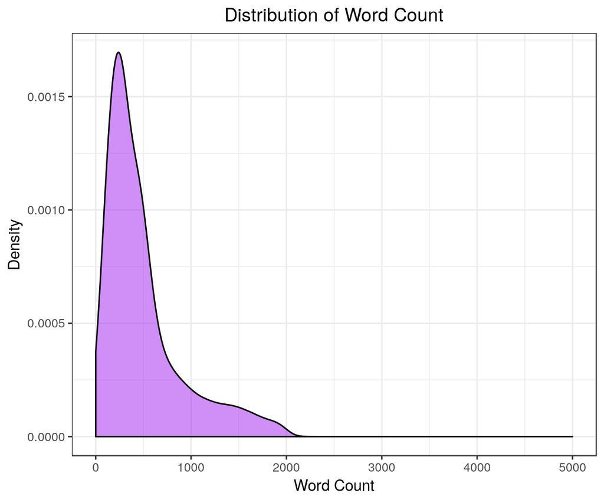

```r
#Distribution
ggplot(dna.2.dt, aes(x = word_count)) +
  geom_density(fill = "purple", alpha = 0.5, adjust = 4, trim = FALSE) +
  labs(
    x = "Word Count",
    y = "Density",
    title = "Distribution of Word Count"
  ) +
  xlim(0, 5000)
```

#### Sources (of Publishers)

```r
#Data frame for all combos of unique codes, names
asd <- dna.2.dt[, list(source_code, source_name, publisher_name)] %>% unique()

#Unique source codes
dna.2.dt$source_code %>% unique() %>% length()
```

```
## [1] 1642
```

```r
#" " names
dna.2.dt$source_name %>% unique() %>% length()
```

```
## [1] 1690
```

```r
#Unique publisher names
dna.2.dt$publisher_name %>% unique() %>% length()
```

```
## [1] 659
```

```r
#Joining for unique data frame (writen out)
asd <- left_join(asd, dna.2.dt[, list(source_code, source_name, publisher_name)] %>%
                   group_by(source_code) %>%
                   summarise(
                     count_source_code = n()
                   ), by = "source_code")

asd <- left_join(
  asd, dna.2.dt[, list(source_code, source_name, publisher_name)] %>%
    group_by(source_name) %>%
    summarise(
      count_source_name = n()
    ), by = "source_name"
)

asd <- left_join(
  asd, dna.2.dt[, list(source_code, source_name, publisher_name)] %>%
    group_by(publisher_name) %>%
    summarise(
      count_publisher_name = n()
    ), by = "publisher_name"
)

#write_csv(unique(asd), "./data/working/DNA_Aggregated/unique_publisher_sources.csv")

#Top 10 Unique Names
dna.2.dt %>%
  group_by(publisher_name) %>%
  summarise(
    Count = n()
  ) %>%
  arrange(desc(Count)) %>%
  dt_mutate(
    publisher_name = publisher_name %>%
      as.factor() %>%
      forcats::fct_reorder(., Count)
  ) %>%
  slice(1:10)
```

```
##                            publisher_name Count
## 1                              NewsRx.com 83135
## 2                             NewsRX, LLC 64071
## 3               Dow Jones & Company, Inc. 54317
## 4                        HT Media Limited 16204
## 5                     Theflyonthewall.com 10614
## 6                   Elsevier Science Ltd. 10538
## 7                    Close-Up Media, Inc.  9845
## 8  Athena Information Solutions Pvt. Ltd.  7904
## 9                     Business Wire, Inc.  6457
## 10            News Bites Pty Ltd (Europe)  5562
```

[figure not shown]

#### Company Names

Look at unique company names and the top 10 mentioned in these articles for 2014 (in combination with others).

```r
#Str_split to get list of char vectors of region
dna.2.dt <- dna.2.dt %>%
  dt_mutate(
    company_codes = str_split(company_codes, ",") %>%
      lapply(., function(x) {x[c(-1, -length(x))]})    #storing subj codes as nested list of char vector
  )

#Unique
dna.2.dt$company_codes %>%
  unlist() %>%
  unique() %>%
  length()
```

```
## [1] 29301
```

```r
#Summary
company.counts <- dna.2.dt$company_codes %>% map_dbl(.x = ., ~length(.x))
company.counts %>% summary()
```

```
##    Min. 1st Qu.  Median    Mean 3rd Qu.    Max.
##   0.000   3.000   4.000   5.968   6.000 311.000
```

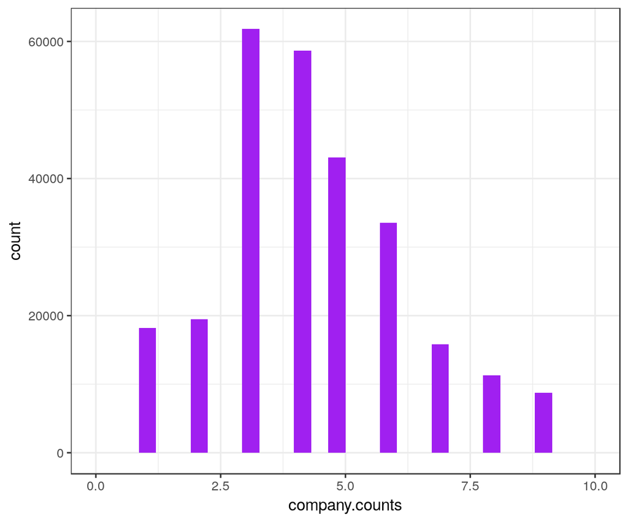

```r
#Histogram
tibble(company.counts = company.counts) %>%
  ggplot(aes(x = company.counts)) +
  geom_histogram(fill = "purple") +
  # geom_density(fill = "purple", adjust = 5) +
  xlim(0, 10)
```

```r
#Top 10
data.table(company = dna.2.dt$company_codes %>%
             unlist() %>%
             table() %>%
             names(),
           counts = dna.2.dt$company_codes %>%
             unlist() %>%
             table() %>%
             as.numeric()) %>%
  dt_arrange(counts) %>%
  Rev(margin = 1) %>%
  slice(1:10)
```

```
##    company counts
## 1    seexc 103307
## 2    usfda  51793
## 3   fffaim  36861
## 4     pfiz  26281
## 5     glxo  20396
## 6   nasdaq  17705
## 7   medinc  17291
## 8   brstmy  16445
## 9    zenec  14947
## 10   lilye  13178
```

#### Company Names (About)

Look at unique company names (about) and the top 10 mentioned in these articles for 2014 (in combination with others).

```r
#Str_split to get list of char vectors of region
dna.2.dt <- dna.2.dt %>%
  dt_mutate(
    company_codes_about = str_split(company_codes_about, ",") %>%
      lapply(., function(x) {x[c(-1, -length(x))]})    #storing subj codes as nested list of char vector
  )

#Unique
dna.2.dt$company_codes_about %>%
  unlist() %>%
  unique() %>%
  length()
```

```
## [1] 13460
```

```r
#Summary
company.counts <- dna.2.dt$company_codes_about %>% map_dbl(.x = ., ~length(.x))
company.counts %>% summary()
```

```
##    Min. 1st Qu.  Median    Mean 3rd Qu.    Max.
##   0.000   1.000   1.000   1.168   1.000  64.000
```

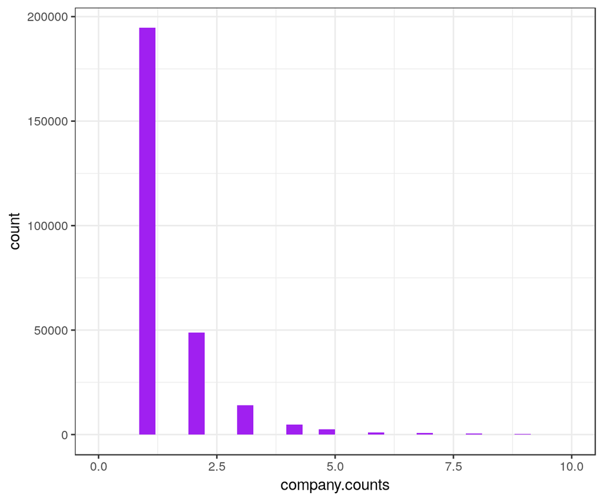

```r
#Histogram
tibble(company.counts = company.counts) %>%
  ggplot(aes(x = company.counts)) +
  geom_histogram(fill = "purple") +
  # geom_density(fill = "purple", adjust = 5) +
  xlim(0, 10)
```

```r
#Top 10
data.table(company = dna.2.dt$company_codes_about %>%
             unlist() %>%
             table() %>%
             names(),
           counts = dna.2.dt$company_codes_about %>%
             unlist() %>%
             table() %>%
             as.numeric()) %>%
  dt_arrange(counts) %>%
  Rev(margin = 1) %>%
  slice(1:10)
```

```
##    company counts
## 1    usfda  13635
## 2     pfiz   6990
## 3     glxo   6149
## 4   medinc   5114
## 5   brstmy   4947
## 6   schplo   4765
## 7    zenec   4133
## 8    lilye   3882
## 9   tychea   3691
## 10  gilsci   3622
```

```r
#Notes

#- Articles w/ no company codes
#- Count how many only fda, sec, and nasdaq (locate, filter)
#- Subject_code, new_product (investigate?) ns? C22 new product? CDNN innovation, cgvfil gov files?
#- Filtering by keywords "in the text body" / subject code?
#- iterate "for all years"
```

#### Articles With No Company Code?

```r
#Company Codes About
map_lgl(.x = company.about$company_codes_about, is_empty) %>% sum()
map_lgl(company.about$company_codes_about, is_empty) %>% mean()

#Company Codes
map_lgl(.x = company$company_codes, is_empty) %>% sum()
map_lgl(company$company_codes, is_empty) %>% mean()

#Both
map2_lgl(.x = company$company_codes, .y = company.about$company_codes_about, ~is_empty(.x) & is_empty(.y)) %>%
  sum()
map2_lgl(.x = company$company_codes, .y = company.about$company_codes_about, ~is_empty(.x) & is_empty(.y)) %>%
  mean() %>%
  round(4)

#Either
map2_lgl(.x = company$company_codes, .y = company.about$company_codes_about, ~is_empty(.x) | is_empty(.y)) %>%
  sum()
map2_lgl(.x = company$company_codes, .y = company.about$company_codes_about, ~is_empty(.x) | is_empty(.y)) %>%
  mean() %>%
  round(4)
```

[output not shown]

The data suggest that 70141 “Company Codes About” are missing, or roughly 0.2074 proportion of the data; while for companies 28872 are empty, comprising roughly 0.0854 of these data. Considering the overlap between these two missing values, 28872 are missing both company and company about; comprising roughly 0.0854 proportion of the data. Lastly, 70141 are missing either value, comprising 0.2074 proportion of the data from 2014.

#### Locate and Filter Company (FDA, SEC, NASDAQ)

```r
#Filtered df by company != FDA, SEC, or NASDAQ
dna.3.dt <- dna.2.dt %>%
  dt_mutate(
 #   company_codes = str_split(company_codes, ",") %>%
#      lapply(., function(x) {x[c(-1, -length(x))]}),    #storing subj codes as nested list of char vector
#    company_codes_about = str_split(company_codes_about, ",") %>%
#      lapply(., function(x) {x[c(-1, -length(x))]}),    #storing subj codes as nested list of char vector
    filter_company = ifelse(map_lgl(.x = company_codes, ~length(.x) != 1),
                            FALSE,
                            map_lgl(.x = company_codes, ~str_detect(.x, "usfda|seexc|nasdaq") %>% any(isTRUE(.)))),
    filter_company_about = ifelse(map_lgl(.x = company_codes_about, ~length(.x) != 1),
                                  FALSE,
                                  map_lgl(.x = company_codes_about, ~str_detect(.x, "usfda|seexc|nasdaq") %>% any(isTRUE(.))))
  )

#Count how many have only fda, sec, nasdaq in company, company about, or either.
dna.3.dt$filter_company %>% sum()
```

```
## [1] 2091
```

```r
dna.3.dt$filter_company_about %>% sum()
```

```
## [1] 3717
```

```r
(dna.3.dt$filter_company | dna.3.dt$filter_company_about) %>% sum()
```

```
## [1] 5404
```

```r
#Filter out either variable
dna.3.dt <- dna.3.dt %>%
  dt_mutate(
    filter_either = dna.3.dt$filter_company | dna.3.dt$filter_company_about
  ) %>%
  dt_filter(filter_either != TRUE) %>%
  dt_select(-c(filter_company, filter_company_about, filter_either))
```

#### Industry Investigation

```r
#Number of Unique Industry codes
dna.3.dt <- dna.3.dt %>%
  dt_mutate(
    industry_codes_empty =  map(.x = industry_codes, ~ifelse(.x %in% "", character(0), .x)),
    industry_codes = str_split(industry_codes, ",") %>%
      lapply(., function(x) {x[c(-1, -length(x))]}),    #storing industry codes as nested list of char vector
    industry_codes = map(.x = industry_codes, ~ifelse(.x %in% "", character(0), .x))
  )

#Industry codes
#Pharmaceuticals
#Number of Empty INdustry Codes
map_lgl(.x = dna.3.dt$industry_codes_empty, ~is.na(.x)) %>% sum()
```

```
## [1] 0
```

```r
map_lgl(.x = dna.3.dt$industry_codes_empty, ~is.na(.x)) %>% mean()
```

```
## [1] 0
```

```r
#Most Common Industry Codes (10)
data.table(industry = dna.3.dt$industry_codes %>%
             unlist() %>%
             table() %>%
             names(),
           counts = dna.3.dt$industry_codes %>%
             unlist() %>%
             table() %>%
             as.numeric()) %>%
  dt_arrange(counts) %>%
  Rev(margin = 1) %>%
  slice(1:10)
```

```
##    industry counts
## 1      i951 332843
## 2      i257 247610
## 3      i372 119815
## 4   idrugty  88276
## 5    iphmed  74492
## 6     i2569  74023
## 7  itheradv  42801
## 8    ibioph  42408
## 9    ifinal  20671
## 10    itech  13119
```

```r
#Pharma
map_lgl(.x = dna.3.dt$industry_codes, ~c("i257") %in% .x) %>% sum()
```

```
## [1] 247610
```

```r
#Medical Equipment/Supplies
map_lgl(.x = dna.3.dt$industry_codes, ~c("i372") %in% .x ) %>% sum()
```

```
## [1] 119815
```

```r
#Remove FDA Source Codes (from publisher)
dna.3.dt <- dna.3.dt %>%
  dt_mutate(
    source_filter = str_detect(source_code, paste0(c("USFOD", "WCUSFOD", "FDADOC", "FDADB", "FDDB"), collapse = "|"))
  )

#Number of Publisher sources coming from FDA
dna.3.dt$source_filter %>% sum()
```

```
## [1] 1702
```

```r
#Filter and remove sourc_filter variable
dna.3.dt <- dna.3.dt %>%
  dt_filter(source_filter %in% FALSE) %>%
  dt_select(-source_filter)
```

#### Summary of Final (FDA & WC) Filtered Data

```r
#Dimension
dim(dna.3.dt)
```

```
## [1] 331141     34
```

```r
#Summary of final data
str(dna.3.dt)
```

[output not shown]

[output cut: 381 more lines]

[output not shown]